# W3cubDocs

/D3.js 5

# d3-geo-polygon

Clipping and geometric operations for spherical polygons.

## Installing

If you use NPM, `npm install d3-geo-polygon`. Otherwise, download the [latest release](https://github.com/d3/d3-geo-polygon/releases/latest). You can also load directly from [unpkg](https://unpkg.com/d3-geo-polygon/). AMD, CommonJS, and vanilla environments are supported. In vanilla, a `d3` global is exported:

```
<script src="https://unpkg.com/d3-geo@1"></script>
<script src="https://unpkg.com/d3-geo-polygon@1"></script>
<script>

// new projection
var projection = d3.geoDodecahedral();

// polyhedral projections don’t need SVG or canvas clipping anymore
var projection = d3.geoPolyhedralCollignon();

// arbitrary polygon clipping on any projection
var projection = d3.geoEquirectangular()
    .preclip(d3.geoClipPolygon({
      type: "Polygon",
      coordinates: [[[-10, -10], [-10, 10], [10, 10], [10, -10], [-10, -10]]]
    }));

</script>
```

## API Reference

###### d3.**geoClipPolygon**(*polygon*) [Source](https://github.com/d3/d3-geo-polygon/blob/master/src/clip/polygon.js)

Given a GeoJSON *polygon* or *multipolygon*, returns a clip function suitable for *projection*.preclip.

###### clip.**polygon**()

Given a clipPolygon function, returns the GeoJSON polygon.

## Projections

d3-geo-polygon adds polygon clipping to the polyhedral projections from d3-geo-projection. Thus, it supercedes the following symbols:

###### d3.**geoPolyhedral**(*tree*, *face*) [Source](https://github.com/d3/d3-geo-polygon/blob/master/src/polyhedral/index.js)

Defines a new polyhedral projection. The *tree* is a spanning tree of polygon face nodes; each *node* is assigned a *node*.transform matrix. The *face* function returns the appropriate *node* for a given *lambda* and *phi* in radians.

###### *polyhedral*.**tree**() returns the spanning tree of the polyhedron, from which one can infer the faces’ centers, polygons, shared edges etc.

###### d3.**geoPolyhedralButterfly**() [Source](https://github.com/d3/d3-geo-polygon/blob/master/src/polyhedral/butterfly.js)

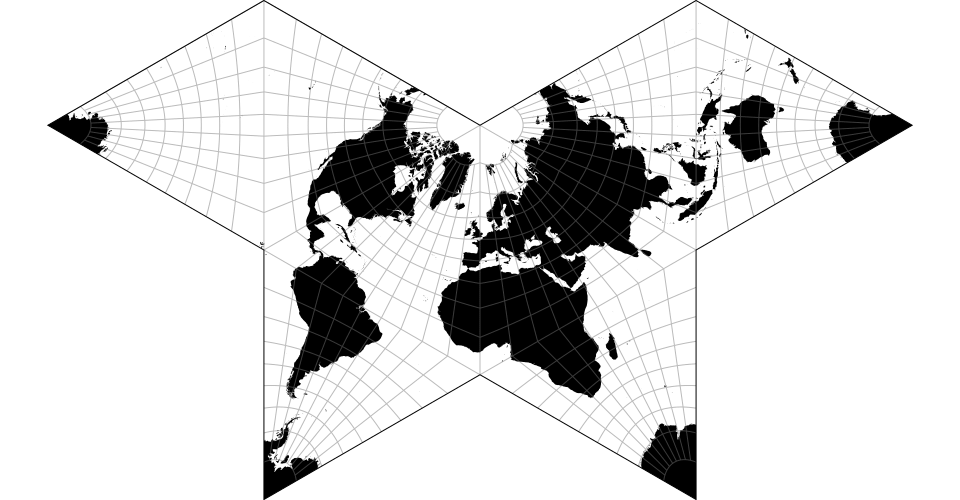

The gnomonic butterfly projection.

###### d3.**geoPolyhedralCollignon**() [Source](https://github.com/d3/d3-geo-polygon/blob/master/src/polyhedral/collignon.js)

[figure not shown]

The Collignon butterfly projection.

###### d3.**geoPolyhedralWaterman**() [Source](https://github.com/d3/d3-geo-polygon/blob/master/src/polyhedral/waterman.js)

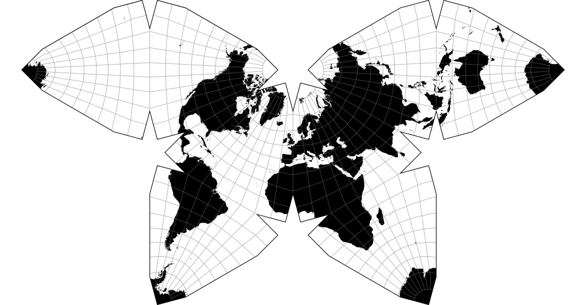

A butterfly projection inspired by Steve Waterman’s design.

New projections are introduced:

###### d3.**geoPolyhedralVoronoi**([*parents*], [*polygons*], [*faceProjection*], [*faceFind*]) [Source](https://github.com/d3/d3-geo-polygon/blob/master/src/polyhedral/voronoi.js)

Returns a polyhedral projection based on the *polygons*, arranged in a tree according to the *parents* list. *polygons* are a GeoJSON FeatureCollection of geoVoronoi cells, which should indicate the corresponding sites (see d3-geo-voronoi). An optional *faceProjection* is passed to d3.geoPolyhedral() -- note that the gnomonic projection on the polygons’ sites is the only faceProjection that works in the general case.

The .**parents**([*parents*]), .**polygons**([*polygons*]), .**faceProjection**([*faceProjection*]) set and read the corresponding options. Use *.faceFind(voronoi.find)* for faster results.

###### d3.**geoCubic**() [Source](https://github.com/d3/d3-geo-polygon/blob/master/src/cubic.js)

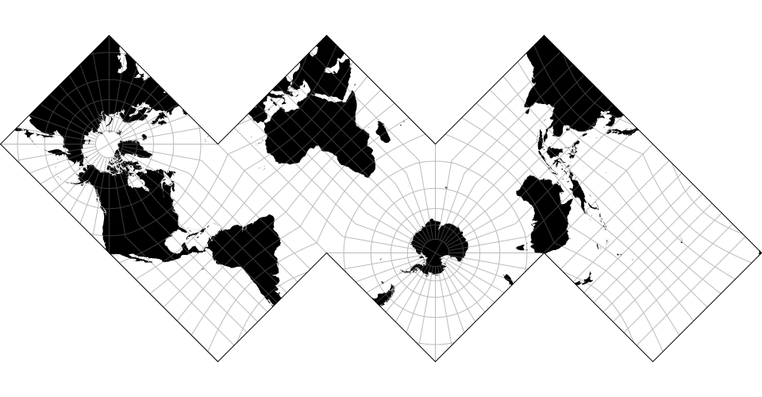

The cubic projection.

###### d3.**geoDodecahedral**() [Source](https://github.com/d3/d3-geo-polygon/blob/master/src/polyhedral/dodecahedral.js)

[figure not shown]

The dodecahedral projection.

###### d3.**geoIcosahedral**() [Source](https://github.com/d3/d3-geo-polygon/blob/master/src/icosahedral.js)

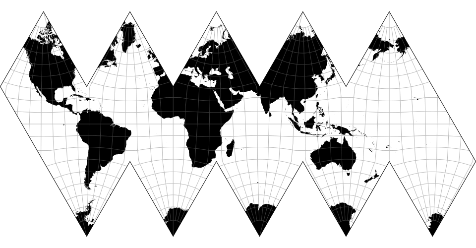

The icosahedral projection.

###### d3.**geoAirocean**() [Source](https://github.com/d3/d3-geo-polygon/blob/master/src/airocean.js)

[figure not shown]

Buckminster Fuller’s Airocean projection (also known as “Dymaxion”), based on a very specific arrangement of the icosahedron which allows continuous continent shapes. Fuller’s triangle transformation, as formulated by Robert W. Gray (and implemented by Philippe Rivière), makes the projection almost equal-area.

###### d3.**geoCahillKeyes**() [Source](https://github.com/d3/d3-geo-polygon/blob/master/src/cahillKeyes.js) d3.**geoCahillKeyes**

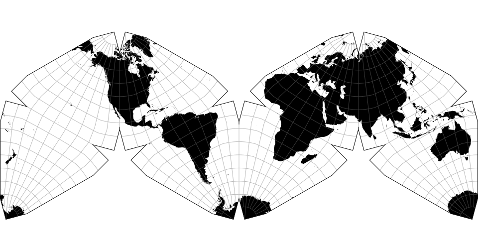

The Cahill-Keyes projection, designed by Gene Keyes (1975), is built on Bernard J. S. Cahill’s 1909 octant design. Implementation by Mary Jo Graça (2011), ported to D3 by Enrico Spinielli (2013).

###### d3.**geoTetrahedralLee**() [Source](https://github.com/d3/d3-geo-polygon/blob/master/src/tetrahedralLee.js) d3.**geoLeeRaw**

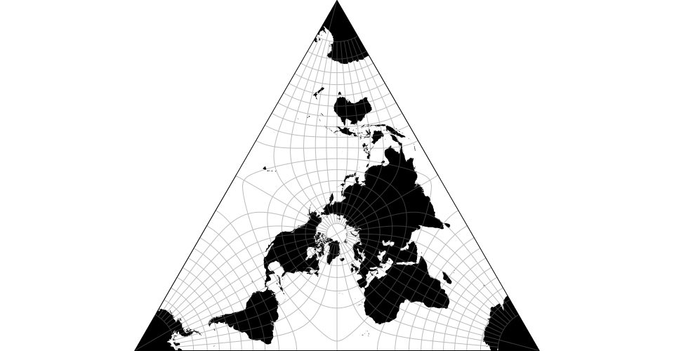

Lee’s tetrahedral conformal projection.

###### Default *angle* is +30°, apex up (-30° for base up, apex down).

Default aspect uses *projection*.rotate([30, 180]) and has the North Pole at the triangle’s center -- use *projection*.rotate([-30, 0]) for the [South aspect](https://beta.observablehq.com/@fil/lee-projection).

###### d3.**geoCox**() [Source](https://github.com/d3/d3-geo-polygon/blob/master/src/cox.js) d3.**geoCoxRaw**

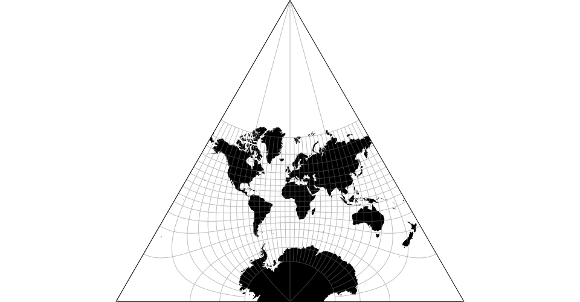

The Cox conformal projection.

© 2010–2018 Michael Bostock  
Licensed under the BSD License.  
https://github.com/d3/d3-geo-polygon